# *The Social Cost of Carbon*

Ethics and the Limits of Climate Change Economics

Author

Affiliation

J. Paul Kelleher

Bioethics & Philosophy, UW–Madison

Published

March 11, 2026

## What is the Social Cost of Carbon (SCC)?

Representative laudatory descriptors from economists:

- “the most important number you’ve never heard of” (Ackerman and Stanton 2010, p. 2)
- “the single most important variable for [climate] policy analysis” (Pearson 2011, p. 78)
- the “holy grail of climate economic analysis” (Wagner 2020)
- “the one number that rules them all, the one number that every government across the globe should use” (Auffhammer 2017, at 4m26s)
- “[t]he most important single economic concept in the economics of climate change” (Nordhaus 2017, p. 1518)

## What is the Social Cost of Carbon (SCC)?

More formal (also from economists):

- The present discounted value of all the impacts from an extra ton of carbon dioxide emissions.

My gloss:

- A packaging of all the impacts from an extra ton of carbon dioxide emissions (from tomorrow into an indefinite future), typically expressed as a single monetary figure (or a range of such figures), and intended for use in economic evaluation and analysis.

**Book aims**

1. Describe the role that ethical assumptions must (and must not) play in SCC estimates.
2. Describe the role that ethics-informed SCC estimates can (and cannot) play in climate change policy evaluation.
3. Put the book’s findings to work to evaluate changes implemented by the Biden administration for the conduct of economic policy analysis.

**Book’s distinctive claims**

1. There are two families of SCC estimates, and ethical assumptions are relevant to only one of the families.
2. Ethics bears on how *any* SCC value—from *either* family—should be used in policy analysis.
3. *All* existing SCC estimates are “normatively abridged” (i.e. normatively incomplete).
4. The Biden adminstration was correct to move policy analysis in a more utilitarian direction, but did not go far enough in doing so.

## The Received View

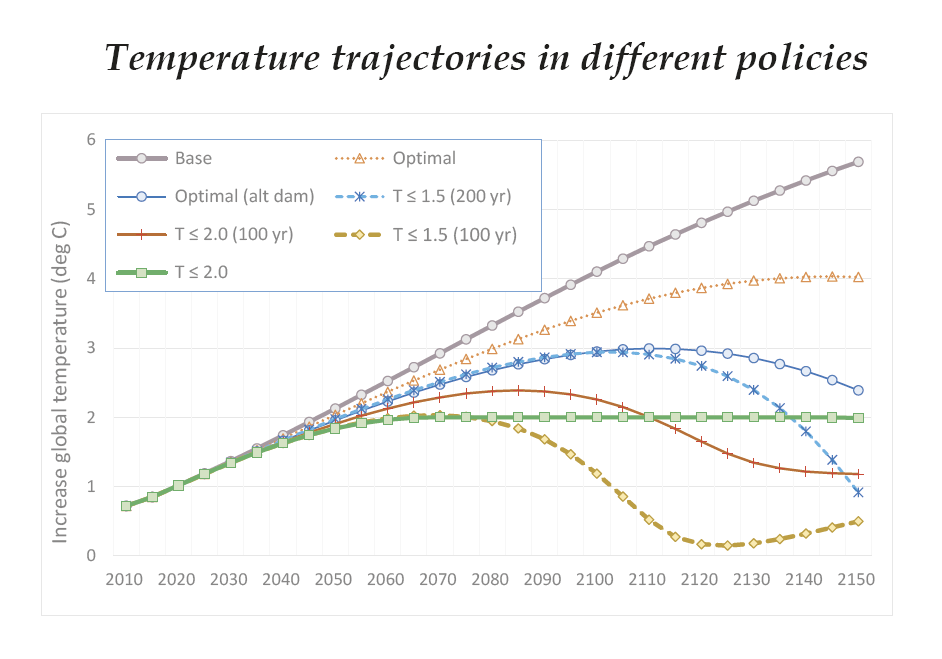

Nordhaus (2018)

## The Received View

[figure not shown]

Stern drew…

“…a simple conclusion: the benefits of strong and early action far outweigh the economic costs of not acting.”  
(Stern 2007, p. xv)

Nordhaus’s 2008 SCC: $8 / ton of CO$_2$

Stern’s 2007 SCC: $85 / ton of CO$_2$

## The Received View

*Like many other studies of the economics of global warming, the* Stern Review *puts policy decisions about how to balance emissions reductions with damages in the framework of economic growth theory. In this framework…[p]olicies change the trajectory of emissions, GHG concentrations, impacts, and consumption. Alternative paths of climate policies and consumption are then evaluated by using* *a social welfare function that ranks the different paths*.

(Nordhaus 2008, p. 171, emphasis added)

*Although some economists are skeptical about SWFs [social welfare functions]…this is not true of economists working on climate change. The SWF methodology is pervasive in this literature. For example, both the* Stern Review *and Nordhaus’ book* A Question of Balance *employ an SWF as the fundamental tool for evaluating carbon-reduction policies. Their policy differences are profound—but because of a disagreement about the parameters of the SWF…and not because of a disagreement about the methodology itself.* (Adler and Treich 2015, p. 282)

The book argues that these exegetical claims are mistaken.

## The Social Choice Methodology

Begin with a set of feasible aggregate consumption paths of the form:

$$( C_{0} ,N_{0} ,C_{1} ,N_{1} ,\ ...\ ,C_{t} ,N_{t} ,\ ... )$$

Now introduce a mathematical function that assigns a ranking-score to each path:

$$\begin{equation}
\label{eq:SWF_util}
V=\sum\limits _{t=0}^{T} N_{t} \cdot w\left(\frac{C_{t}}{N_{t}}\right) \cdot \frac{1}{( 1+\delta )^{t}}
\end{equation}$$

with

$$w(c_{t}) =\frac{c_{t}^{1-\eta }}{1-\eta }$$

## The General Equilibrium Methodology

Concerned to…

1. predict/project real-world status quo outcomes given economic fundamentals
2. provide economic recipes for guiding the economy to pre-chosen Pareto efficient outcomes

## The General Equilibrium Methodology

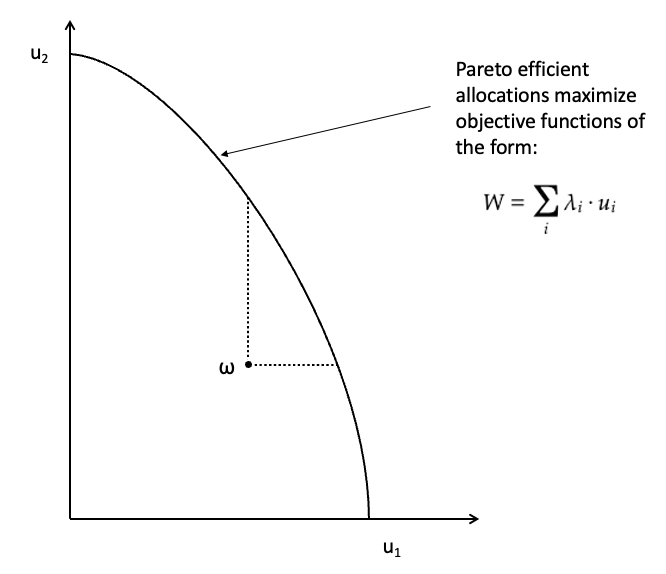

Using many (standard) assumptions in economic growth theory, these *characterizing* functions take the form:

## The General Equilibrium Methodology

Characterizing functions:

$$\begin{equation}
\label{eq:character_function}
W=\sum\limits _{t=0}^{T} N_{t} \cdot u\left(\frac{C_{t}}{N_{t}}\right) \cdot \frac{1}{( 1+\theta )^{t}}
\end{equation}$$

Compare with the standard social choice social welfare function:

$$\begin{equation} \tag{1}
V=\sum\limits _{t=0}^{T} N_{t} \cdot w\left(\frac{C_{t}}{N_{t}}\right) \cdot \frac{1}{( 1+\delta )^{t}}
\end{equation}$$

## Two Families of SCCs

$$\begin{equation} \tag{2}
W=\sum\limits _{t=0}^{T} N_{t} \cdot u\left(\frac{C_{t}}{N_{t}}\right) \cdot \frac{1}{( 1+\theta )^{t}}
\end{equation}$$

$$\begin{equation} \tag{1}
V=\sum\limits _{t=0}^{T} N_{t} \cdot w\left(\frac{C_{t}}{N_{t}}\right) \cdot \frac{1}{( 1+\delta )^{t}}
\end{equation}$$

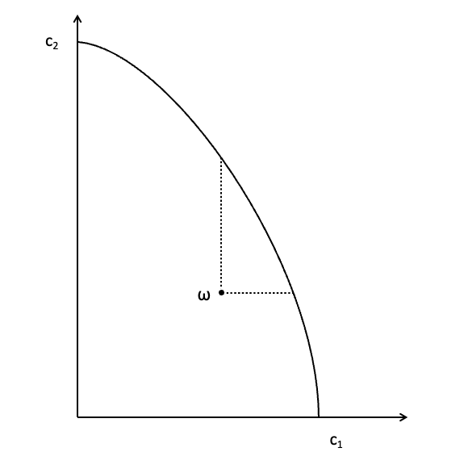

- Two families, four concepts

## Toward Defensible SCCs

- The book axiomatically motivates and partially defends *undiscounted* utilitarian social welfare functions.
- It argues that both utilitarian and prioritarian SWFs are “normatively abridged”—i.e. they do not reflect all policy relevant normative considerations.
- It puts abridged utilitarianism to work to appraise a Biden-era revision of federal cost-benefit analysis guidance (which has since been rescinded by Trump).

Two main conclusions from this appraisal:

1. Biden OMB was correct to allow the use of utilitarian cost-benefit analysis (and the corresponding social choice SCCs).
2. Biden OMB was incorrect (and inconsistent) to insist that discount rates in cost-benefit analysis be “descriptive”.

## References

Ackerman, F., and Stanton, E. A. 2010. *The Social Cost of Carbon: A Report for the Economics for Equity and the Environment Network*.

Adler, M. D., and Treich, N. 2015. “Prioritarianism and Climate Change,” *Environmental & Resource Economics* (62:2), pp. 279–308.

Auffhammer, M. 2017. *Social Cost of Carbon*.

Nordhaus, W. D. 2008. *A Question of Balance*, Yale University Press.

Nordhaus, W. D. 2017. “Revisiting the Social Cost of Carbon,” *Proceedings of the National Academy of Sciences* (114:7), pp. 1518–1523.

Nordhaus, W. D. 2018. *Climate Change: The Ultimate Challenge for Economics (2018 Nobel Prize Lecture)*.

Pearson, C. S. 2011. *Economics and the Challenge of Global Warming*, Cambridge University Press.

Stern, N. 2007. *The Economics of Climate Change: The Stern Review*, Cambridge, UK: Cambridge University Press.

Wagner, G. 2020. “Why Oil Giants Figured Out Carbon Costs First,” *Bloomberg.com*.